# Analysis - Tristan da Cunha vessel traffic in ATBA

## Identifying transits

To identify transits through the ATBA we first selected all of the locations by vessels over 400 gross tons within the ATBA. We then identified the `trip_id` associated with each of these positions, and selected every location associated with each `trip_id`.

A `trip_id` is associated with all of the vessel locations between two **port visits**. For the purposes of this analysis, we considered that a port visit had occurred when a vessel:

1. Entered port (vessel within 3km of port)
2. Was stationary (speed less than 0.2 knots) or stopped transmitting its location for more than 4 hours
3. Exited port (vessel more than 4km from port)

This query pulls all positions from port-to-port trips that passed within the ATBA:

```r
query_4 <- readr::read_file(str_c("queries", "q_tdc_atba_trips_through_atba_all_positions.sql", sep="/"))
```

Run the query:

```r
vt_atba_tracks <- fishwatchr::gfw_query(query = query_4,
                                        run_query = TRUE,
                                        con = con)$data
```

Alternatively, the queried data can be loaded locally here:

```r
vt_atba_tracks <- readr::read_rds("data_production/data/vessl-tracks-over-400t-atba-only.rds")
```

Reformat the data so that `inside_eez`, `inside_atba`, are formatted correctly and extract `date` from `timestamp`:

```r
vt_atba_tracks <- vt_atba_tracks %>%
  mutate(inside_eez = inside_eez %>% as.logical(), # format TRUE/FALSE
         inside_atba = inside_atba %>% as.logical(), # format as TRUE/FALSE
         date = lubridate::date(timestamp)) # extract date
```

Because some vessels may have transited through the ATBA more than once, we needed to create a `transit_id` to differentiate between individual vessel transits. To do this, we wrote a custom function called `create_transit_id()` to create a `transit_id` for each transit, and used `purrr::map()` to iterate through a list of unique vessel ids (`ssvid`). We applied this function to create two `transit_id`s; one for each transit through the EEZ and another for each transit through the ATBA. The steps of the function are:

1. filter the dataframe to the `ssvid` in question
2. arrange by `timestamp`
3. for the first row - assign a `transit_no` as `t` or `NA` depending on whether the point is inside the EEZ/ATBA
4. loop through every subsequent row and:
   1. IF inside atba/eez AND previous position outside: `transit_no <- t`
   2. IF inside AND previous position inside AND previous position within 7 days: `transit_no <- t`
   3. IF inside AND previous position inside AND previous position outside 7 days: `transit_no <- t+1`
   4. IF outside AND previous position inside: `t <- t+1`

The function was defined as:

```r
# ssvid: unique vessel identifier
# df: dataframe including vessel positions
# col_name: name of new column to filter by
# output: output the original dataframe with the new column included, or output the new column as a vector
# time_dif: to avoid assigning multiple transit_ids to a vessel that skirted the edge of the EEZ/ATBA, we included a minimum time period that had to pass before a vessel was assigned a new transit_id (default 7 days)

create_transit_id <- function(ssvid, df, col_name = "inside_atba", output = "df", time_dif = 7){

  # 1. filter df by ssvid and arrange by timestamp
  df_temp <- df %>%
    filter(ssvid == {{ssvid}}) %>%
    arrange(timestamp) %>%
    # create a numericcolumn called transit_no populated with NA
    mutate(transit_no = as.numeric(NA))

  # 2. set an initial transit_no value
  t <- 1

  # 3. for the first row, if inside atba set transit no to t
    if(df_temp[[1, as.character(col_name)]] == TRUE){
    df_temp[[1, "transit_no"]] <- t
  } else {
    # else do nothing
  }

  # 4. loop through each row of df_temp, starting with the second row
  for(i in 2:nrow(df_temp)){

    # if outside atba and previous position was inside
    # increase t by + 1
    if(df_temp[[i, as.character(col_name)]] == FALSE &
              df_temp[[i - 1, as.character(col_name)]] == TRUE){

         t <- t + 1

    # if inside atba and previous position outside
    # assign transit_no t
    } else if(df_temp[[i, as.character(col_name)]] == TRUE &
              df_temp[[i - 1, as.character(col_name)]] == FALSE){

       df_temp[[i,"transit_no"]] <- t

    # if inside atba and previous position was also inside atba
    # and within 1 week
    # then assign transit_no t
    } else if(df_temp[[i, as.character(col_name)]] == TRUE &
       df_temp[[i - 1, as.character(col_name)]] == TRUE &
       as.numeric(df_temp[[i, "date"]] - df_temp[[i - 1, "date"]]) <= time_dif){

        df_temp[[i,"transit_no"]] <- t

    # if inside atba and previous position was also inside atba
    # but more than 1 week later
    # then increase t + 1, and assign transit_no t
    } else if(df_temp[[i, as.character(col_name)]] == TRUE &
       df_temp[[i - 1, as.character(col_name)]] == TRUE &
       as.numeric(df_temp[[i, "date"]] - df_temp[[i - 1, "date"]]) > time_dif){

        t <- t + 1
        df_temp[[i,"transit_no"]] <- t

    } else {
       # do nothing
    }

  }

  # append ssvid and transit_no to create transit_id
  df_temp <- df_temp %>%
    mutate(transit_id = if_else(!is.na(transit_no), str_c(ssvid, as.character(transit_no), sep = "_"), as.character(NA)))

  # return full df or vector depending on specified output
  if(output == "df"){
    return(df_temp)
  } else if(output == "vector"){
    return(df_temp$transit_id)
  } else {
    stop("Invalid output. Must be 'df' or 'vector'")
  }

}
```

Next define the list of ssvids to iterate through:

```r
ssvid_list <- vt_atba_tracks %>% distinct(ssvid) %>% .$ssvid
names(ssvid_list) <- ssvid_list
```

Then iterate `create_transit_id()` over `ssvid_list` using `purrr::map()`.

```r
# first, create a transit_id for each transit through the EEZ
# iterate the function create_transit_id over full ssvid_list using purrr::map()
vt_transits_eez <- purrr::map(.x = ssvid_list,
                         .f = create_transit_id,
                         df = vt_atba_tracks,
                         col_name = "inside_eez",
                         output = "df",
                         time_dif = 7) %>%
  # bind the resulting list of dataframes together
  dplyr::bind_rows() %>%
  # next rename these new columns to include the suffix _eez
  rename(transit_id_eez = transit_id,
         transit_no_eez = transit_no)

# then create a transit_id for each transit through the ATBA
# iterate the function create_transit_id over full ssvid_list using purrr::map()
vt_transits_atba <- purrr::map(.x = ssvid_list,
                         .f = create_transit_id,
                         df = vt_transits,
                         col_name = "inside_atba",
                         output = "df") %>%
  dplyr::bind_rows() %>%
# rename new columns to include the suffix _atba
  rename(transit_id_atba = transit_id,
         transit_no_atba = transit_no)

# cbind transit_no_atba and transit_id_atba to vt_transits_eez
vt_transits <- cbind(vt_transits_eez,
                     vt_transits_atba %>% dplyr::select(transit_no_atba, transit_id_atba))
```

Alternatively, the processed data can be loaded locally here:

```r
vt_transits <- readr::read_rds("data_production/data/vessel-traffic-eez-only-transit_id_fixed_v4.rds")
```

For each `transit_id_eez` we then determined if the vessel:

1. passed through the ATBA
2. slowed below 0.2 knots while inside the ATBA

```r
# which transits passed through the atba
transit_info <- vt_transits %>%
  group_by(transit_id_eez) %>%
  summarise(through_atba = sum(as.numeric(inside_atba)) > 0)

vt_transits <- vt_transits %>%
  merge(transit_info, by = "transit_id_eez", all.x = TRUE)

# which transits slowed while in the atba
transit_speed <- vt_transits %>%
  filter(inside_atba == TRUE) %>%
  group_by(transit_id_eez) %>%
  summarise(slowed_in_atba = min(speed_knots) <= 0.2)

vt_transits <- vt_transits %>%
  merge(transit_speed, by = "transit_id_eez", all.x = TRUE)
```

Which vessels made the most transits? First we summarised the number of transits made through the ATBA, per vessel, per year. Including year allows us to merge these data with the identity information associated with that vessel id that year.

```r
vessels_by_n_transits <- vt_transits %>%
  filter(date >= ymd("2020-04-01"), # only inlucde transits after the ATBA was implemented
         slowed_in_atba == FALSE, # that did not slow below 0.2 knots inside the ATBA
         through_atba == TRUE) %>% # from transits that passed through the atba
  group_by(ssvid, year) %>%
  summarise(n_transits = n_distinct(transit_id_atba, na.rm = TRUE),
            .groups = "keep") # count the number of transit_id_atba values

vessels_by_n_transits
```

| ssvid | year | n_transits |
| --- | --- | --- |
| 111111234 | 2021 | 1 |
| 200006639 | 2021 | 1 |
| 209447000 | 2020 | 1 |
| 209682000 | 2020 | 1 |
| 209854000 | 2020 | 1 |
| 210043000 | 2020 | 1 |
| 210655000 | 2020 | 1 |
| 212460000 | 2021 | 1 |
| 227498430 | 2021 | 1 |
| 227837860 | 2020 | 1 |

[output cut: 123 more lines]

These data were uploaded to BigQuery as `world-fishing-827.scratch_cian.atba_ssvids`. The following query merges the data in `vessels_by_n_transits` with the best information available on vessel identity including the most commonly transmitted vessel name, flag, vessel class, and gross tonnage:

```r
query_5 <- readr::read_file(str_c("queries", "q_tdc_atba_transits_vessel_info.sql", sep="/"))
```

Run query:

```r
vessels_by_n_transits <- fishwatchr::gfw_query(query = query_5,
                                               run_query = TRUE,
                                               con = con)$data
```

Alternatively, the queried data can be loaded locally here:

```r
vessels_by_n_transits <- readr::read_rds("data_production/data/vessels_by_n_transits_v2.rds")
```

After inspecting the data, there appeared to be a number of sailing vessels that passed through the ATBA as part of the [Vendée Globe](https://www.vendeeglobe.org/) round-the-world race. The algorithm used to predict gross tonnage of vessels generally performs well, with a predictive score of 0.77 (see [Kroodsma et al. 2018](https://www.science.org/doi/abs/10.1126/science.aao5646)), but the training data didn’t include long-haul sailing vessels such as these, and subsequently the algorithm may not perform as well for these vessels. Additionally, the risk of these vessels running aground and causing a serious environmental incident, such as that caused by the MS Oliva, is low. Therefore we excluded these vessels from further analysis:

First we created a list of `ssvid`s which most commonly self-reported as `Sailing`, and then filtered out these `ssvid`s from the transit data:

```r
sailing_vessels <- vessels_by_n_transits %>%
  unnest(shiptype) %>%
  group_by(ssvid) %>%
  top_n(1, wt = count) %>%
  filter(value == "Sailing")
```

Looking at these vessels we could see that all of these vessels, with the exception of the `LU HUANG YUAN YU 107` was flagged to FRA. The `LU HUANG YUAN YU 107` is definitely not a sailing vessel, so the self-reported value in this case was not accurate.

If we instead filtered for only French-flagged vessels we got a more conservative list of sailing vessels, and so this was the exclusion criteria we used:

```r
sailing_vessels <- vessels_by_n_transits %>%
  unnest(shiptype) %>%
  group_by(ssvid) %>%
  top_n(1, wt = count) %>%
  filter(best_flag == "FRA")
```

So with that in mind, how many transits occurred before and after the implementation of the ATBA? To answer this we counted the number of distinct `transit_id` values:

```r
# all transits between 01 Jan 2019 - 30 Jun 2020
vt_transits %>%
  filter(slowed_in_atba == FALSE,
         through_atba == TRUE,
         # exclude sailing vessels
         !ssvid %in% sailing_vessels$ssvid) %>%
  mutate(after_atba = date >= ymd("2020-04-01"),
         month = date %>% floor_date("months")) %>%
  group_by(after_atba) %>%
  summarise(n_transits = n_distinct(transit_id_atba, na.rm = TRUE),
            n_vessels = n_distinct(ssvid, na.rm = TRUE))
```

| after_atba | n_transits | n_vessels |
| --- | --- | --- |
| FALSE | 454 | 416 |
| TRUE | 125 | 123 |

```r
# all transits limited to 12 months before/after the implementation of the ATBA
# (01 Apr 2019 - 31 Mar 2020)
vt_transits %>%
  filter(slowed_in_atba == FALSE,
         through_atba == TRUE,
         date %>% between(ymd("2019-04-01"), ymd("2021-03-31")),
         # exclude sailing vessels
         !ssvid %in% sailing_vessels$ssvid) %>%
  mutate(after_atba = date >= ymd("2020-04-01"),
         month = date %>% floor_date("months")) %>%
  group_by(after_atba) %>%
  summarise(n_transits = n_distinct(transit_id_atba, na.rm = TRUE),
            n_vessels = n_distinct(ssvid, na.rm = TRUE))
```

| after_atba | n_transits | n_vessels |
| --- | --- | --- |
| FALSE | 327 | 304 |
| TRUE | 96 | 96 |

Plot the number of transits per vessel flag:

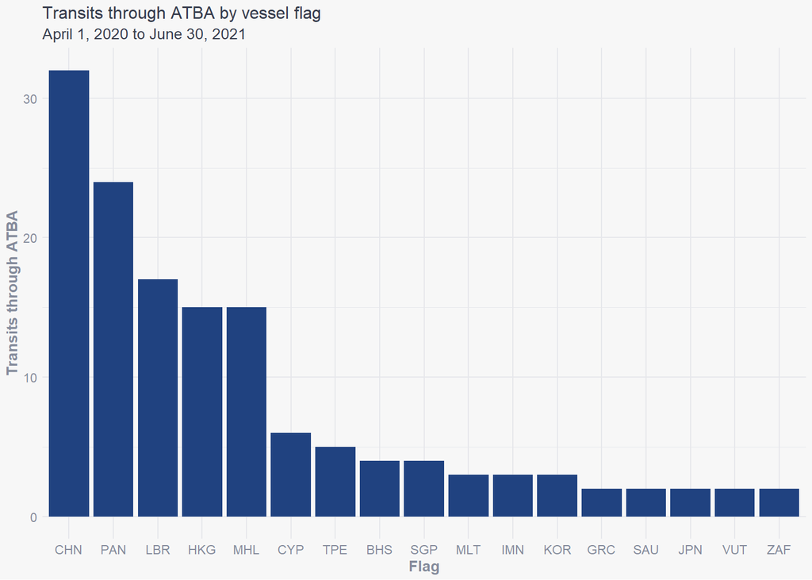

```r
# summarise the number of transits per flag
flag_transit_summary <- vt_transits %>%
  filter(date >= ymd("2020-04-01"),
         through_atba == TRUE,
         slowed_in_atba == FALSE,
         # exclude sailing vessels
         !ssvid %in% sailing_vessels$ssvid) %>%
  mutate(best_flag = best_flag %>% recode_factor("TWN" = "TPE")) %>%
  group_by(best_flag) %>%
  summarise(n_transits = n_distinct(transit_id_atba, na.rm = TRUE)) %>%
  # important for plotting - arrange in descending order by n_transits
  arrange(desc(n_transits))

# plot the number of transits per flag
vt_transits %>%
  filter(date >= ymd("2020-04-01"),
         through_atba == TRUE,
         slowed_in_atba == FALSE,
         !is.na(best_flag),
         # exclude sailing vessels
         !ssvid %in% sailing_vessels$ssvid) %>%
  group_by(best_flag) %>%
  summarise(n_transits = n_distinct(transit_id_atba)) %>%
  # reorder the factor levels of best_flag according to the number of transits per flag
  # useful for making a pretty plot
  mutate(best_flag = best_flag %>%
           recode_factor("TWN" = "TPE") %>%
           factor(levels = flag_transit_summary$best_flag)) %>%
  ggplot() +
    geom_col(aes(x = best_flag, y = n_transits), fill = gfw_palette("chart")[1]) +
    labs(x = "Flag", y = "Transits through ATBA",
         title = "Transits through ATBA by vessel flag",
         subtitle = "April 1, 2020 to June 30, 2021") +
    theme_gfw_cian() +
    theme(plot.title = element_text(size = 16),
          plot.subtitle = element_text(size = 14),
          axis.text = element_text(size = 12),
          axis.title = element_text(size = 14),
          legend.title = element_text(size = 14),
          legend.text = element_text(size = 12))
```

```r
NA
```

Number of transits by vessel class:

```r
# summarise the number of transits per flag
vt_transits %>%
  filter(date >= ymd("2020-04-01"),
         through_atba == TRUE,
         slowed_in_atba == FALSE,
         # exclude sailing vessels
         !ssvid %in% sailing_vessels$ssvid) %>%
  group_by(best_vessel_class) %>%
  summarise(n_transits = n_distinct(transit_id_atba, na.rm = TRUE)) %>%
  arrange(desc(n_transits))
```

| best_vessel_class | n_transits |
| --- | --- |
| cargo | 90 |
| squid_jigger | 20 |
| specialized_reefer | 4 |
| tanker | 3 |
| cargo_or_tanker | 2 |
| drifting_longlines | 2 |
| fishing | 1 |
| gear | 1 |
| non_fishing | 1 |
| set_longlines | 1 |

Map the transits through the ATBA:

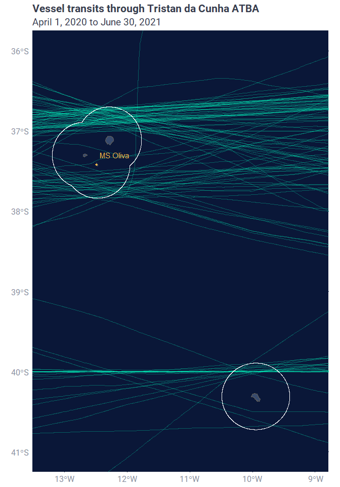

```r
# create a dataframe of the coordinates of where the MS Oliva ran aground
ms_oliva <- data.frame(name = "MV Oliva",
                       lon = -12.493,
                       lat = -37.419)

# This code sets a bounding box for the map area
bounding_atba <- transform_box(xlim = c(-13.3, -9),
                               ylim = c(-41, -36),
                               output_crs = "+proj=longlat +ellps=WGS84 +datum=WGS84 +no_defs")

# use ggplot2 to create a map of transits
vt_transits %>%
  # filter data to only include transits after the ATBA was established
  filter(date >= ymd("2020-04-01"),
         through_atba == TRUE,
         slowed_in_atba == FALSE,
         # exclude sailing vessels
         !ssvid %in% sailing_vessels$ssvid) %>%
  group_by(as.factor(transit_id_eez)) %>%
  arrange(timestamp) %>%
  ggplot() +
  geom_path(aes(x = lon, y = lat, group = transit_id_eez), colour = gfw_palette("map_presence_dark")[3], alpha = 0.3) +
  geom_sf(data = atba_sf, colour = "white", linetype = 1, fill = NA) +
  geom_sf(data = tdc_sf, fill = gfw_palette("map_country_dark")[1]) +
  geom_point(data = ms_oliva, aes(x = lon, y = lat), shape = 18, colour = gfw_palette("sand")[1]) +
  annotate("text", x = -12.2, y = -37.3, colour = gfw_palette("sand")[1], label = "MS Oliva") +
  labs(title = "Vessel transits through Tristan da Cunha ATBA",
       subtitle = "April 1, 2020 to June 30, 2021") +
  theme_gfw_map_cian() +
  theme(plot.title = element_text(size = 16),
        plot.subtitle = element_text(size = 14),
        axis.text = element_text(size = 12),
        legend.title = element_text(size = 14),
        legend.text = element_text(size = 12),
        legend.position = c(0.7, 0.95)) +
  coord_sf(xlim = c(bounding_atba$box_out[['xmin']], bounding_atba$box_out[['xmax']]),
           ylim = c(bounding_atba$box_out[['ymin']], bounding_atba$box_out[['ymax']]),
           crs = bounding_atba$out_crs)
```

For additional context, we plotted the tracks of all squid jiggers that actually transited through the ATBA. First, we made a list of all squid jiggers that transited through the ATBA.

```r
ssvid_squid_2 <- vt_transits %>%
  filter(slowed_in_atba == FALSE,
         through_atba == TRUE,
         best_vessel_class == "squid_jigger") %>%
  distinct(ssvid) %>%
  pull(ssvid)
```

We then ran a modified version of the original query to select all of the port-to-port positions from the squid jigger vessels in `vt_transits`.

```r
query_6 <- readr::read_file(str_c("queries", "q_tdc_atba_squid_jigger_transits_fishing.sql", sep="/"))
```

Run the query:

```r
squid_tracks_2 <- fishwatchr::gfw_query(query = query_6,
                                        run_query = TRUE,
                                        con = con)$data
```

Filter to only keep trips that transit through the ATBA:

```r
squid_tracks_2 <- squid_tracks_2 %>%
  group_by(trip_id) %>%
  summarise(through_atba = sum(inside_atba) > 0) %>%
  merge(squid_tracks_2, by = "trip_id", all.y = TRUE) %>%
  filter(through_atba == TRUE)
```

Alternatively, the queried data can be loaded locally here:

```r
squid_tracks_2 <- read_rds("data_production/data/squid_jigger_tracks_full.rds")
```

Create a map of these tracks including locations of fishing activity:

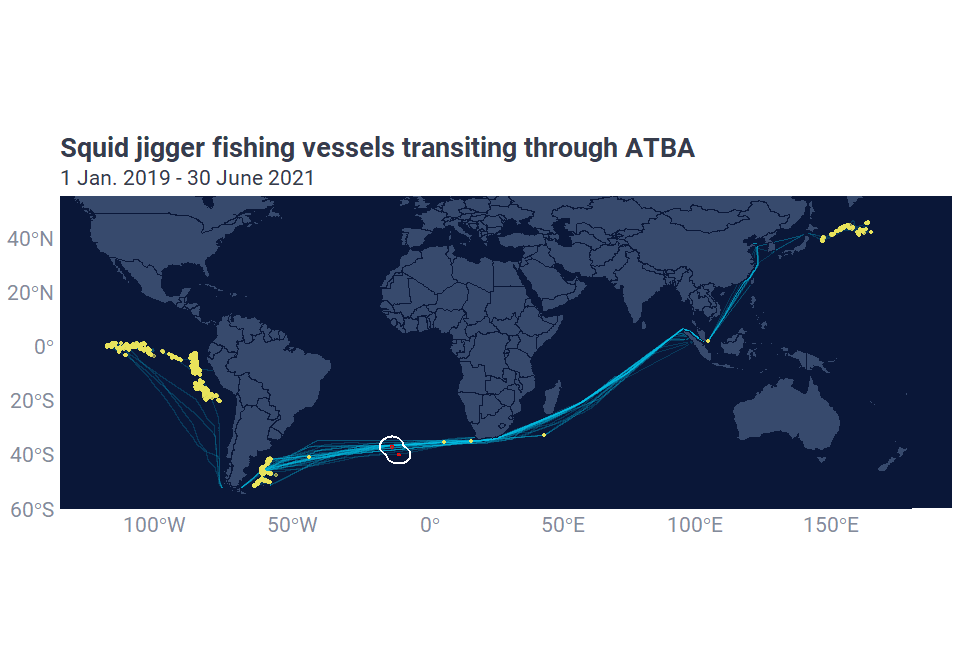

```r
# filter out trips that cross 180 longitude
# these are difficult to map
trip_sum <- squid_tracks_2 %>%
  group_by(trip_id) %>%
  summarise(keep = min(lon) > -120) %>%
  filter(keep == TRUE)

# set the bounding area for the map
bounding_3 <- transform_box(xlim = c(-120, 180),
                            ylim = c(-55, 50),
                            output_crs = "+proj=longlat +ellps=WGS84 +datum=WGS84 +no_defs")

# use ggplot to create the map
squid_tracks_2 %>%
  filter(trip_id %in% trip_sum$trip_id) %>%
  arrange(timestamp) %>%
  ggplot() +
    geom_path(aes(x = lon, y = lat, group = trip_id), colour = gfw_palette("tracks")[1], alpha = 0.2) +
    # geom_gfw_eez(lwd = 1) +
    geom_sf(data = eez_tdc, fill = NA, colour = "white", size = 1) +
    geom_gfw_land() +
    geom_sf(data = atba_sf, colour = "red", linetype = 1, fill = NA) +
    geom_sf(data = tdc_sf, fill = gfw_palette("map_country_dark")[1]) +
    geom_point(data = squid_tracks_2 %>% filter(fishing_hours > 0),
               aes(x = lon, y = lat),
               colour = gfw_palette("yellow")[1], size = 1, alpha = 0.2) +
    labs(title = "Squid jigger fishing vessels transiting through ATBA",
         subtitle = "1 Jan. 2019 - 30 June 2021") +
    theme_gfw_map_cian() +
    theme(plot.title = element_text(size = 20),
          plot.subtitle = element_text(size = 16),
          axis.text = element_text(size = 16),
          legend.title = element_text(size = 20),
          legend.text = element_text(size = 16)) +
    coord_sf(xlim = c(bounding_3$box_out[['xmin']], bounding_3$box_out[['xmax']]),
             ylim = c(bounding_3$box_out[['ymin']], bounding_3$box_out[['ymax']]),
             crs = bounding_3$out_crs)
```

## Distance to shore

Here we used the `sf` (simple features) package to work out the distance to shore for every position within the ATBA. To save computing time we excluded all points outside of the ATBA. We created a `row_id` in `vt_transits` to merge results.

Create an `sf` object of points within the ATBA, and only include necessary columns to save computing time:

```r
# create a row_id col in vt_transits for merging
vt_transits <- vt_transits %>%
  mutate(row_id = seq(1, nrow(vt_transits), length.out = nrow(vt_transits)))

# filter to just positions inside the atba
vt_atba_sf <- vt_transits %>%
  filter(inside_atba == TRUE) %>%
  dplyr::select(row_id, lat, lon) %>%
  st_as_sf(coords = c('lon', 'lat'), crs = 4326)
```

`sf::st_ditance(vt_atba_sf, tdc_sf)` calculates the Euclidean distance (in metres) between each point of `vt_atba_sf` and each feature of `tdc_sf` (shapefile of the Tristan da Cunha arhcipelago), returning a distance matrix. `apply(1, min)` then iterates through each row of this matrix and selects the minimum distance for each row - i.e. the minimum distance between each point of `vt_atba_sf` and the closest feature of `tdc_sf`.

```r
vt_atba_sf$dist_to_shore_m <- st_distance(vt_atba_sf, tdc_sf) %>%
  apply(1, min)
```

Merged back with `vt_transits`:

```r
vt_transits <- vt_transits %>%
  merge(vt_atba_sf %>% st_drop_geometry(),
        by = "row_id", all.x = TRUE)
```

Converted distance from metres to kilometres and round to 2 decimal places:

```r
vt_transits <- vt_transits %>%
  mutate(dist_to_shore_km = round(dist_to_shore_m/1000, 2))
```

Updated the list of vessels to include min distance to shore. First we calculated the min distance to shore for each transit, and then merged the results with `vt_transits` using `transit_id_atba`:

```r
# minimum distance to shore for every transit passing through the atba
transit_dist <- vt_transits %>%
  # slowed_in_atba == FALSE key to eliminate non transits
  filter(date >= ymd("2020-04-01"),
         !is.na(transit_id_atba),
         inside_atba == TRUE,
         slowed_in_atba == FALSE) %>%
  group_by(transit_id_atba) %>%
  summarise(min_dist_to_shore_km = min(dist_to_shore_km, na.rm = TRUE))

# merge distances with vt_transits
vt_transits <- vt_transits %>%
  merge(transit_dist, by = "transit_id_atba", all.x = TRUE)
```

Updated the list of transiting vessels:

```r
vessels_by_dist <- vt_transits %>%
  filter(date >= ymd("2020-04-01"),
         !is.na(transit_id_atba),
         through_atba == TRUE,
         slowed_in_atba == FALSE) %>%
  group_by(ssvid) %>%
  summarise(min_dist_to_shore_km = min(min_dist_to_shore_km, na.rm = TRUE)) %>%
  merge(vessels_by_n_transits) %>%
  arrange(min_dist_to_shore_km, best_flag)

# create a version that excludes sailing vessels
vessels_by_dist_no_sailing <- vessels_by_dist %>% filter(!ssvid %in% sailing_vessels$ssvid)
```

## Are vessels avoiding the ATBA?

What proportion of transits that passed through the EEZ also passed through the ATBA? Does this proportion change during the 12 months before and after the implementation of the ATBA?

```r
# before ATBA
vt_transits %>%
  filter(date %>% between(ymd("2019-04-01"), ymd("2020-03-31")),
         # exclude sailing vessels
        !ssvid %in% sailing_vessels$ssvid) %>%
  group_by(transit_id_eez) %>%
  summarise(n_transits = n_distinct(transit_id_eez, na.rm = TRUE),
            through_atba = n_distinct(transit_id_atba, na.rm = TRUE) > 0) %>%
  summarise(n_transits_eez = sum(n_transits),
            n_transits_atba = sum(through_atba),
            prop_through_atba = n_transits_atba/n_transits_eez)
```

| n_transits_eez | n_transits_atba | prop_through_atba |
| --- | --- | --- |
| 344 | 340 | 0.9883721 |

```r
# after ATBA
vt_transits %>%
  filter(date %>% between(ymd("2020-04-01"), ymd("2021-03-31")),
         # exclude sailing vessels
        !ssvid %in% sailing_vessels$ssvid) %>%
  group_by(transit_id_eez) %>%
  summarise(n_transits = n_distinct(transit_id_eez, na.rm = TRUE),
            through_atba = n_distinct(transit_id_atba, na.rm = TRUE) > 0) %>%
  summarise(n_transits_eez = sum(n_transits),
            n_transits_atba = sum(through_atba),
            prop_through_atba = n_transits_atba/n_transits_eez)
```

| n_transits_eez | n_transits_atba | prop_through_atba |
| --- | --- | --- |
| 112 | 103 | 0.9196429 |

Did vessel traffic (hours of vessel activity) through the EEZ and ATBA change after the ATBA was implemented?

```r
# eez
vt_transits %>%
  filter(inside_eez == TRUE,
         !ssvid %in% sailing_vessels$ssvid,
         date %>% between(ymd("2019-04-01"), ymd("2021-03-31"))) %>%
  mutate(after_atba = date >= ymd("2020-04-01")) %>%
  group_by(after_atba) %>%
  summarise(total_vessel_hours = sum(hours, na.rm = TRUE))
```

| after_atba | total_vessel_hours |
| --- | --- |
| FALSE | 17924.226 |
| TRUE | 7204.513 |

```r
# atba
vt_transits %>%
  filter(inside_atba == TRUE,
         !ssvid %in% sailing_vessels$ssvid,
         date %>% between(ymd("2019-04-01"), ymd("2021-03-31"))) %>%
  mutate(after_atba = date >= ymd("2020-04-01")) %>%
  group_by(after_atba) %>%
  summarise(total_vessel_hours = sum(hours, na.rm = TRUE))
```

| after_atba | total_vessel_hours |
| --- | --- |
| FALSE | 5753.908 |
| TRUE | 3106.623 |

# Port to port tracking

Using the same methodology, as described above, to identify likely port visits, we wanted to identify the port that each vessel was travelling from and to when it transited through the ATBA. To do this, we used the `trip_id` associated with every trip that included a transit through the ATBA, to look up the name of the ports visited before and and after each transit.

First, we created a list of the `trip_id`s for transits passing through the ATBA, post-implementation:

```r
transits_post_atba[1:10]
```

```
 [1] "111111234-017452bc9608" "200006639-01741ea66b28" "209447000-0175b77f1f38" "209682000-017145ed8fe8" "209854000-0174e92587a8" "210043000-017385d2d670"
 [7] "210655000-0175ee56e2e8" "212460000-01776ca0a7a0" "229609000-0178229fcf90" "229623000-0171b32245e0"
```

Then we defined a query to identify the names and locations of ports visited before and after transiting through the ATBA:

```r
query_7 <- readr::read_file(str_c("queries", "q_tdc_atba_ports_visited_exclude_singapore.sql", sep="/"))
```

Run query:

```r
transit_ports <- fishwatchr::gfw_query(query = query_7,
                                       run_query = TRUE,
                                       con = con)$data
```

Alternatively, the queried data can be loaded locally here:

```r
transit_ports <- readr::read_rds("data_production/data/transit_ports_c4.rds")
```

To make a map of origin and destination ports we needed to reformat the `transit_ports` dataframe into a long version, with port label, lon, lat, and number of voyages starting and ending there. Some ports had multiple anchorage points associated with them. In these cases we grouped the anchorages by `port_label` and averaged the lon and lat coordinates.

```r
# create long version of dataframe
# filter to only include ports of origin
# create a col called cat (short for category) and populate with "origin"
ports_origin <- transit_ports %>%
  filter(!is.na(trip_start_anchorage_label)) %>%
  mutate(port_label = str_c(trip_start_anchorage_label, trip_start_anchorage_country, sep = ", ")) %>%
  group_by(port_label) %>%
  summarise(n_voyages = n(),
            lon = mean(trip_start_anchorage_lon, na.rm = TRUE),
            lat = mean(trip_start_anchorage_lat, na.rm = TRUE)) %>%
  mutate(cat = "origin")

# note there are 6 fewer destinations as 6 trips were still active at the end of our time range
# and hadn't yet reached a port

# filter to only include ports of origin
# create a col called cat (short for category) and populate with "origin"
ports_destination <- transit_ports %>%
  filter(!is.na(trip_end_anchorage_label)) %>%
  mutate(port_label = str_c(trip_end_anchorage_label, trip_end_anchorage_country, sep = ", ")) %>%
  group_by(port_label) %>%
  summarise(n_voyages = n(),
            lon = mean(trip_end_anchorage_lon, na.rm = TRUE),
            lat = mean(trip_end_anchorage_lat, na.rm = TRUE)) %>%
  mutate(cat = "destination")

# bind the two dataframes together
ports_long <- rbind(ports_origin, ports_destination)
```

Here we created a map with points showing the locations of each port and the points sized in proportion to the number of transits beginning or ending there:

```
Spherical geometry (s2) switched off
```

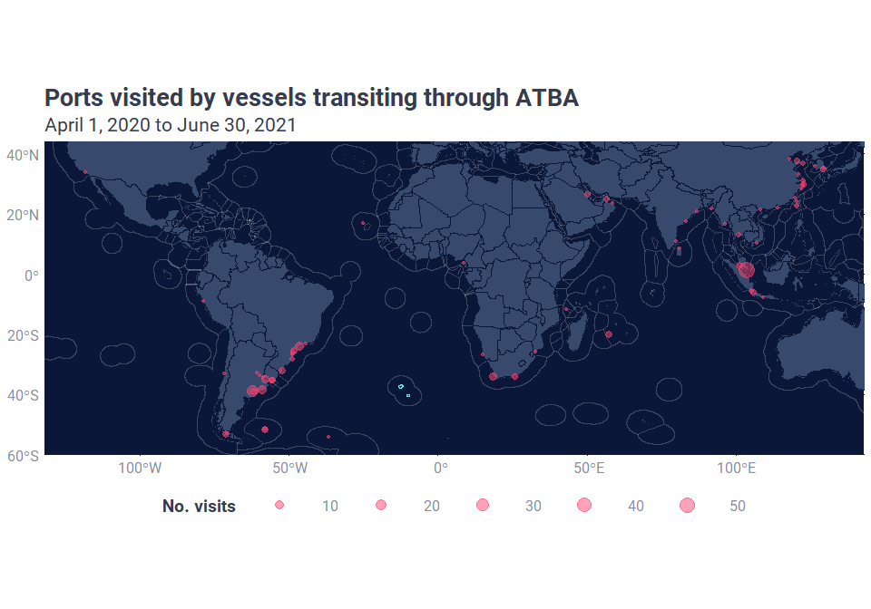

```r
# set the bounding are for the map
bounding_ports <- fishwatchr::transform_box(xlim = c(min(ports_long$lon) - 1,
                                                     max(ports_long$lon) + 1),
                                            ylim = c(min(ports_long$lat) - 1,
                                                     max(ports_long$lat) + 1),
                                            output_crs = "+proj=longlat +ellps=WGS84 +datum=WGS84 +no_defs")

# create the map using ggplot2
ports_long %>%
  # here we wanted to summarise the number of pots starting OR ending in each port
  # so we used group_by(port_label), excluding the origin/destination category
  group_by(port_label) %>%
  summarise(n_voyages = sum(n_voyages), .groups = "keep",
            lon = mean(lon),
            lat = mean(lat)) %>%
    ggplot() +
  fishwatchr::geom_gfw_eez(theme = 'dark') +
  fishwatchr::geom_gfw_land(theme = 'dark') +
  geom_point(aes(x = lon, y = lat, size = n_voyages), alpha = 0.5, colour = gfw_palette("map_reception_light")[4]) +
  scale_size_continuous(name = "No. visits") +
  geom_sf(data = atba_sf, colour = gfw_palette("diverging")[1], linetype = 1, fill = NA) +
  geom_sf(data = tdc_sf, fill = gfw_palette("map_country_dark")[1]) +
  labs(title = "Ports visited by vessels transiting through ATBA",
       subtitle = "April 1, 2020 to June 30, 2021") +
  theme_gfw_map_cian(theme = 'dark') +
  theme(legend.position = "bottom",
        plot.title = element_text(size = 20),
        plot.subtitle = element_text(size = 16),
        axis.text = element_text(size = 12),
        legend.title = element_text(size = 14),
        legend.text = element_text(size = 12)) +
  coord_sf(xlim = c(bounding_ports$box_out[['xmin']], bounding_ports$box_out[['xmax']]),
           ylim = c(bounding_ports$box_out[['ymin']], bounding_ports$box_out[['ymax']]),
           crs = bounding_ports$out_crs)
```

Next we plotted the number of transits that started or ended in the 10 ports most frequently visited by transiting vessels:

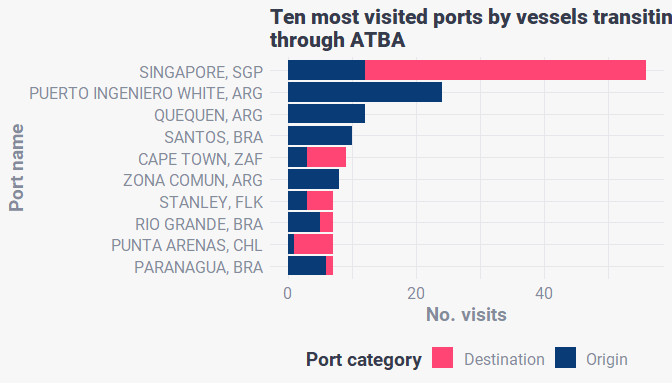

```r
# create a summary table of the top 10 most visited ports
# useful for plotting
ports_sum_top10 <- ports_long %>%
  group_by(port_label) %>%
  summarise(n_voyages = sum(n_voyages)) %>%
  top_n(10, n_voyages) %>%
  arrange(n_voyages)

# create a horizontal barplot coloured by the number of transits that started or ended in each port
ports_long %>%
  filter(port_label %in% ports_sum_top10$port_label) %>%
  ggplot(aes(y = port_label %>% factor(levels = ports_sum_top10 %>% pull(port_label)),
             x = n_voyages, fill = cat)) +
  geom_col() +
  scale_fill_manual(values = gfw_palette('map_reception_light', type = "discrete")[c(4,2)],
                    name = "Port category",
                    labels = c("Destination", "Origin")) +
  labs(x = "No. visits",
       y = "Port name",
       title = "Ten most visited ports by vessels transiting\nthrough ATBA") +
  theme_gfw_cian() +
  theme(axis.title = element_text(size = 14),
        axis.text = element_text(size = 12),
        plot.title = element_text(size = 16),
        legend.title = element_text(size = 14),
        legend.text = element_text(size = 12),
        legend.position = "bottom")
```

We created a wide table of transits ending and beginning in each port to be included as an appendix in the final report.

```r
ports_wide <- ports_long %>%
  pivot_wider(names_from = cat,
              values_from = n_voyages,
              values_fill = 0) %>%
  separate(port_label, c('port','country'), sep = ", ", remove = FALSE) %>%
  arrange(country) %>%
  dplyr::select(-port, -country)
```

# Gaps in AIS transmission

To understand how gaps in AIS transmission may affect our ability to detect transiting vessels, we used a dataset of suspected AIS disabling events. The methodology is currently under peer review, but in short, this dataset applies a classification model to gap events longer than 12 hours to identify potential disabling of AIS devices. This model accounts for the quality of satellite reception, the location and duration of a gap event, and the rate of AIS transmission before and after the gap occurred.

This query pulls all AIS gap events longer than 12 hours near Tristan da Cunha (between -25° and 5° longitude, and -25° and -50° latitude) between Jan. 2019 and June 2021. The query includes only gap events longer than 12 hours as satellite reception can vary a lot in shorter time periods. We used a minimum distance to shore of 10 nautical miles to exclude vessels stationary vessels at Tristan. We only kept AIS gap events where the gap started or ended in a location from where 5 or more locations had been transmitted to exclude gaps occurring in low reception areas. Finally, based on previous analysis, we considered gap events where the vessel had transmitted 19 or more AIS positions in the 12 hours previous to a 12 hour gap to represent potential disabling of AIS devices.

```r
query_8 <- readr::read_file(str_c("queries", "q_tdc_atba_gap_events.sql", sep="/"))
```

Run the query:

```r
gap_events <- fishwatchr::gfw_query(query = query_8,
                                    run_query = TRUE,
                                    con = con)$data
```

Alternatively, the queried data can be loaded locally here:

```r
gap_events <- read_rds("data_production/data/ais_gaps_intentional.rds")
```

We reformatted the data into a structure including a column for:

- `gap_id`: the identity code assigned to each gap event
- `ssvid`: unique vessel identifier
- `gap_hours`: duration of the gap event in hours
- `gap_start`: date and timestamp of when the gap event begun (i.e. when the AIS device was turned off)
- `gap_end`: date and timestamp of when the gap event ended (i.e. when the AIS device was turned back on)
- `vessel_tonnage_gt`: gross tonnage of the vessel
- `vessel_class`: best known vessel class - in this dataset all vessels are fishing vessel classes
- `gap_event`: `off` (AIS turned off) or `on` (AIS device turned on)
- `lon`: longitude in decimal degrees
- `lat`: latitude in decimal degrees

Note, that with the exception of `gap_event`, `lon`, and `lat`, the data for each `gap_id` are duplicated, with one row for the `on` and one row for the `off` position. This is for mapping purposes, and to avoid double counting gaps, we use `n_distinct(gap_id)` to count the number of distinct values of `gap_id`.

```r
gap_events_long <- gap_events %>%
  mutate(off = str_c(off_lon, off_lat, sep = ","),
         on = str_c(on_lon, on_lat, sep = ",")) %>%
  dplyr::select(gap_id, ssvid, gap_hours, gap_start, gap_end, off, on, vessel_tonnage_gt, vessel_class) %>%
  pivot_longer(off:on,
               names_to = "gap_event",
               values_to = "lonlat") %>%
  separate(lonlat,
           into = c("lon", "lat"),
           sep = ",") %>%
  mutate(lon = lon %>% as.numeric(),
         lat = lat %>% as.numeric())
```

Which gaps crossed the EEZ? Here we converted transits into spatial objects and use the spatial function `sf::st_intersects()` to return a TRUE/FALSE column for which transits intersected with the EEZ

```r
# convert transits to a spatial linestring object
gaps_sf <- gap_events_long %>%
  st_as_sf(coords = c('lon', 'lat'), crs = 4326) %>%
  group_by(gap_id) %>%
  summarise(do_union = FALSE) %>%
  st_cast('LINESTRING')

# use sf::st_intersects to return TRUE/FALSE for each transit that crossed the EEZ
gaps_sf$crosses_eez <- st_intersects(gaps_sf, eez_tdc, sparse = FALSE) %>% as.logical()
```

```
although coordinates are longitude/latitude, st_intersects assumes that they are planar
```

```r
# merge this information to the gap_events_long dataframe using gap_id
gap_events_long <- merge(
  x = gap_events_long,
  y = gaps_sf %>% st_drop_geometry(),
  by = "gap_id",
  all.x = TRUE
)
```

How many gap events were detected by vessels belonging to each vessel class and vessel flag?

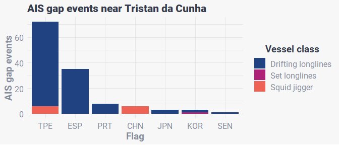

```r
# summarise gap events per flag and vessel class
# arrange in descending order of number of gaps
# this allows us to arrange the vessel flags in the next plot by number of gap events
gap_summary <- gap_events %>%
  group_by(flag, vessel_class) %>%
  summarise(n_gaps = n_distinct(gap_id),
            gap_duration = mean(gap_hours)) %>%
  arrange(desc(n_gaps))
# plot the number of gap events per flag as a bar plot
# colour each barplot by vessel category
gap_summary %>%
  mutate(flag = flag %>%
           factor(levels = distinct(gap_summary, flag) %>%
                    pull(flag)) %>%
                    recode_factor("TWN" = "TPE")) %>%
ggplot() +
    geom_col(aes(x = flag, y = n_gaps, fill = vessel_class)) +
    scale_fill_manual(values = gfw_palette("chart")[c(1,3,5)],
                      name = "Vessel class",
                      labels = c("Drifting longlines", "Set longlines", "Squid jigger")) +
    labs(x = "Flag",
         y = "AIS gap events",
         title = "AIS gap events near Tristan da Cunha") +
    theme_gfw_cian() +
    theme(plot.title = element_text(size = 16),
          plot.subtitle = element_text(size = 14),
          axis.title = element_text(size = 14),
          axis.text = element_text(size = 12),
          legend.title = element_text(size = 14),
          legend.text = element_text(size = 12))
```

Map of AIS gap events by fishing vessels, faceted by vessel class (excluding set_longlines):

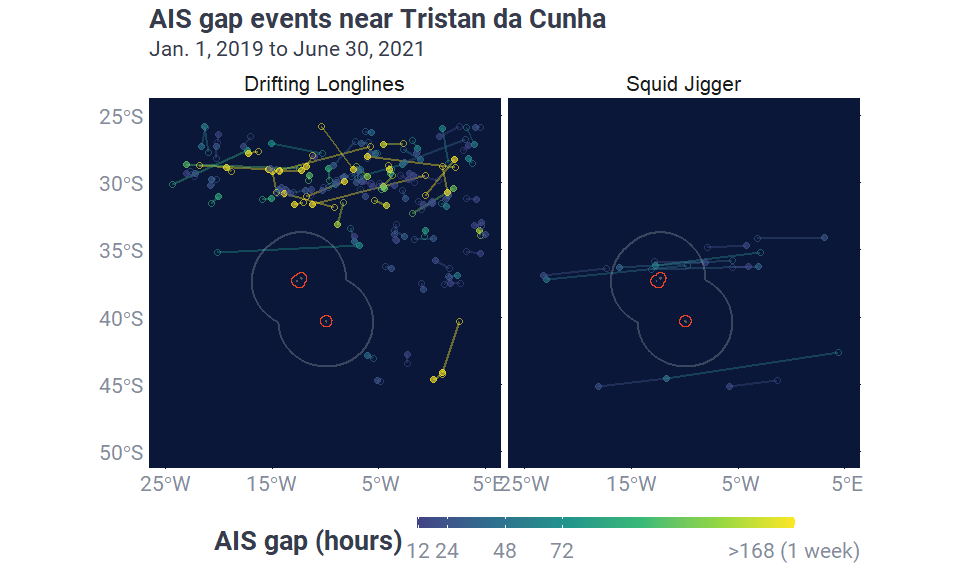

```r
# create vessel category labels for labelling map facets
vcat_labs <- c(squid_jigger = "Squid Jigger", drifting_longlines = "Drifting Longlines")

# set bounding area
bounding_2 <- transform_box(xlim = c(-25, 5),
                            ylim = c(-50, -25),
                            output_crs = "+proj=longlat +ellps=WGS84 +datum=WGS84 +no_defs")

# map of gaps
gap_events_long %>%
  # create a new column gap_hours_alt that associates a gap duration with the off point
  # this allows us to map the colour fill of the point to the gap duration
  mutate(gap_hours_alt = if_else(gap_event == "off", gap_hours, as.numeric(NA))) %>%
  filter(vessel_class != "set_longlines") %>%
  ggplot() +
  geom_path(aes(x = lon, y = lat, colour = gap_hours, group = gap_id), size = 1, alpha = 0.4) +
  geom_point(aes(x = lon, y = lat, colour = gap_hours, fill = gap_hours_alt), size = 2, shape = 21, alpha = 0.6) +
  geom_gfw_eez(lwd = 1) +
  geom_sf(data = atba_sf, colour = gfw_palette("primary")[1], linetype = 1, fill = NA) +
  geom_sf(data = tdc_sf, fill = gfw_palette("map_country_dark")[1]) +
  facet_grid(~ vessel_class,
             labeller = labeller(vessel_class = vcat_labs)) +
  labs(title = "AIS gap events near Tristan da Cunha",
       subtitle = "Jan. 1, 2019 to June 30, 2021") +
  scale_colour_viridis_c(name = "AIS gap (hours)",
                         begin = 0.2,
                         end = 1.0,
                         option = "viridis",
                         limits = c(12, 168),
                         oob = scales::squish,
                         breaks = c(12, 24, 48, 72, 168),
                         labels = c("12", "24", "48", "72", ">168 (1 week)")) +
  scale_fill_viridis_c(name = "AIS gap (hours)",
                         begin = 0.2,
                         end = 1.0,
                         option = "viridis",
                         limits = c(12, 168),
                         oob = scales::squish,
                         breaks = c(12, 24, 48, 72, 168),
                         labels = c("12", "24", "48", "72", ">168 (1 week)"),
                       na.value = NA) +
  scale_alpha_manual(values = c(0, 1)) +
  scale_x_continuous(breaks = c(-25, -15, -5, 5)) +
  guides(fill = "none", alpha = "none") +
  theme_gfw_map_cian() +
  theme(plot.title = element_text(size = 20),
        plot.subtitle = element_text(size = 16),
        axis.text = element_text(size = 16),
        legend.title = element_text(size = 20),
        legend.text = element_text(size = 16),
        strip.text = element_text(size = 16)) +
  coord_sf(xlim = c(bounding_2$box_out[['xmin']], bounding_2$box_out[['xmax']]),
           ylim = c(bounding_2$box_out[['ymin']], bounding_2$box_out[['ymax']]),
           crs = bounding_2$out_crs)
```

Looking at this map we can see that the straight-line interpolations between off and on positions for a number of AIS gap events traversed Tristan da Cunha’s EEZ. Most of these gap events were associated with squid jigger fishing vessels. Next, we wanted to look at the extended tracks of these vessels to assess whether these gap events were atypical of normal vessel activity.

```r
# create a list of vessel ids associated with squid jigger fishing vessels
# with AIS gap events
ssvid_squid <- gap_events %>%
  filter(vessel_class == "squid_jigger") %>%
  distinct(ssvid) %>%
  pull(ssvid)
```

Tweak my original track query to pull the above tracks for 2019-2020 from the `pipe_production_YYYYMMDD_fishing` table

```r
query_9 <- readr::read_file(str_c("queries", "q_tdc_atba_squid_jigger_voyages_gaps.sql", sep="/"))
```

Run the query:

```r
squid_tracks <- fishwatchr::gfw_query(query = query_9,
                                   run_query = TRUE,
                                   con = con)$data
```

Alternatively, the queried data can be loaded locally here:

```r
squid_tracks <- read_rds("data_production/data/squid_jigger_tracks_gaps.rds")
```

Query all the gap events along these tracks for these 10 vessels:

```r
query_10 <- readr::read_file(str_c("queries", "q_tdc_atba_squid_jigger_gap_events.sql", sep="/"))
```

Run the query:

```r
squid_gaps <- fishwatchr::gfw_query(query = query_10,
                                    run_query = TRUE,
                                    con = con)$data
```

Alternatively, the queried data can be loaded locally here:

```r
squid_gaps <- read_rds("data_production/data/ais_gaps_squid.rds")
```

Create a map of these tracks with all associated gap events:

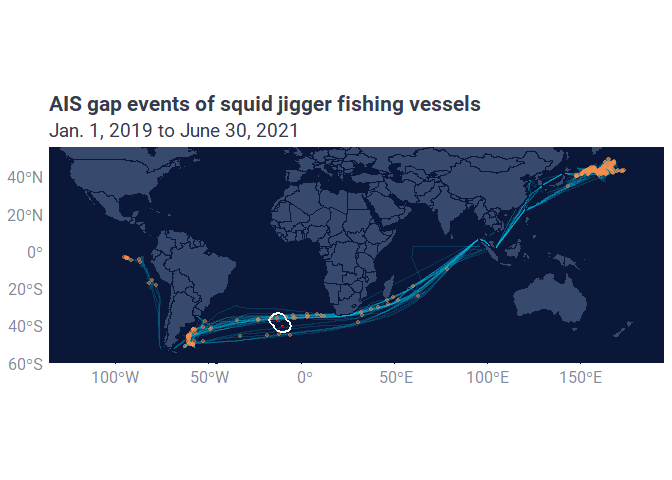

```r
# filter out trips that cross 180° longitude
# these are complicated to map
trip_sum <- squid_tracks %>%
  group_by(trip_id) %>%
  summarise(keep = min(lon) > -120) %>%
  filter(keep == TRUE)

# set bounding area
bounding_3 <- transform_box(xlim = c(-120, 180),
                            ylim = c(-55, 50),
                            output_crs = "+proj=longlat +ellps=WGS84 +datum=WGS84 +no_defs")

# map tracks and gap events
squid_tracks %>%
  # keep only tracks that don't cross 180° longitude
  filter(trip_id %in% trip_sum$trip_id) %>%
  arrange(timestamp) %>%
  ggplot() +
    geom_path(aes(x = lon, y = lat, group = trip_id), colour = gfw_palette("tracks")[1], alpha = 0.2) +
    geom_sf(data = eez_tdc, fill = NA, colour = "white", size = 1) +
    geom_gfw_land() +
    geom_sf(data = atba_sf, colour = "red", linetype = 1, fill = NA) +
    geom_sf(data = tdc_sf, fill = gfw_palette("map_country_dark")[1]) +
  # add gap events as points
    geom_point(data = squid_gaps, aes(x = off_lon, y = off_lat), colour = gfw_palette("orange")[1], size = 1, alpha = 0.4) +
    labs(title = "AIS gap events of squid jigger fishing vessels",
         subtitle = "Jan. 1, 2019 to June 30, 2021") +
    theme_gfw_map_cian() +
    theme(plot.title = element_text(size = 16),
          plot.subtitle = element_text(size = 14),
          axis.text = element_text(size = 12)) +
    coord_sf(xlim = c(bounding_3$box_out[['xmin']], bounding_3$box_out[['xmax']]),
             ylim = c(bounding_3$box_out[['ymin']], bounding_3$box_out[['ymax']]),
             crs = bounding_3$out_crs)
```